# Machine Learning Assignment

Isa Watanabe

August 27, 2016

## Introduction

Using devices such as Jawbone Up, Nike FuelBand, and Fitbit it is now possible to collect a large amount of data about personal activity relatively inexpensively. These type of devices are part of the quantified self movement - a group of enthusiasts who take measurements about themselves regularly to improve their health, to find patterns in their behavior, or because they are tech geeks. One thing that people regularly do is quantify how much of a particular activity they do, but they rarely quantify how well they do it. In this project, the goal will be to use data from accelerometers on the belt, forearm, arm, and dumbell of 6 participants.

## Getting the data

```r
#Download the data
if(!file.exists("./data")){dir.create("./data")}
trainingUrl <- "https://d396qusza40orc.cloudfront.net/predmachlearn/pml-training.csv"
testingUrl <-  "https://d396qusza40orc.cloudfront.net/predmachlearn/pml-testing.csv"
download.file(trainingUrl, destfile = "./data/training.csv")
download.file(testingUrl, destfile = "./data/testing.csv")

#Create training and testing data sets
training <- read.csv(file = "./data/training.csv", header = TRUE, na.strings=c("NA","#DIV/0!",""))
testing <- read.csv(file = "./data/testing.csv", header = TRUE, na.strings=c("NA","#DIV/0!",""))
```

## Loading required packages

```r
library(caret)
```

```r
library(ggplot2)
library(rpart)
library(rpart.plot)
library(rattle)
library(kernlab)
```

## Cleaning the Training Data

Remove NonZeroVariance Varaibles

```r
dim(training)
```

```
## [1] 19622   160
```

```r
NZV <- nearZeroVar(training, saveMetrics = TRUE)

training <- subset(training, select = -(which(NZV$zeroVar == TRUE | NZV$nzv == TRUE)))

dim(training)
```

```
## [1] 19622   124
```

### Remove the row index and subject names (the model should be able to predict exercise class without knowing the specific subject) + other vars

```r
#Get column indexes for columns to remove
toRem <- na.omit(c(
        match('X', names(training)),
        match('user_name', names(training)),
        match('raw_timestamp_part_1', names(training)),
        match('raw_timestamp_part_2',names(training)),
        match('cvtd_timestamp', names(training)),
        match('new_window', names(training)),
        match('num_window', names(training))))
training <- subset(training, select = -c(toRem))

dim(training)
```

```
## [1] 19622   118
```

### Remove Features with over 50% NAs

```r
naVars <- c(NA)
for(i in 1:length(training)){
        if(sum(is.na(training[,i]))/length(training[,i]) >= 0.5) {
               naVars[i] <- i
        }
}

naVars <- na.omit(naVars)
training <- subset(training, select = -c(naVars))


dim(training)
```

```
## [1] 19622    53
```

```r
names(training)
```

```
##  [1] "roll_belt"            "pitch_belt"           "yaw_belt"
##  [4] "total_accel_belt"     "gyros_belt_x"         "gyros_belt_y"
##  [7] "gyros_belt_z"         "accel_belt_x"         "accel_belt_y"
## [10] "accel_belt_z"         "magnet_belt_x"        "magnet_belt_y"
## [13] "magnet_belt_z"        "roll_arm"             "pitch_arm"
## [16] "yaw_arm"              "total_accel_arm"      "gyros_arm_x"
## [19] "gyros_arm_y"          "gyros_arm_z"          "accel_arm_x"
## [22] "accel_arm_y"          "accel_arm_z"          "magnet_arm_x"
## [25] "magnet_arm_y"         "magnet_arm_z"         "roll_dumbbell"
## [28] "pitch_dumbbell"       "yaw_dumbbell"         "total_accel_dumbbell"
## [31] "gyros_dumbbell_x"     "gyros_dumbbell_y"     "gyros_dumbbell_z"
## [34] "accel_dumbbell_x"     "accel_dumbbell_y"     "accel_dumbbell_z"
## [37] "magnet_dumbbell_x"    "magnet_dumbbell_y"    "magnet_dumbbell_z"
## [40] "roll_forearm"         "pitch_forearm"        "yaw_forearm"
## [43] "total_accel_forearm"  "gyros_forearm_x"      "gyros_forearm_y"
## [46] "gyros_forearm_z"      "accel_forearm_x"      "accel_forearm_y"
## [49] "accel_forearm_z"      "magnet_forearm_x"     "magnet_forearm_y"
## [52] "magnet_forearm_z"     "classe"
```

## Coerce All Columns to Numeric Data Type

```r
for(i in 1:(length(training)-1)){
        training[,i] <- as.numeric(training[,i])

}
```

## Create Training and Testing data sets

```r
#We need to split the Training Dataset into a training and testing dataset
set.seed(346)
inTrain <- createDataPartition(y=training$classe, p=0.7, list = FALSE)
modTrain <- training[inTrain,]
modTest <- training[-inTrain,]
```

## Building our Model

I chose to use a decison tree tocreate my model. Honestly, random forests took too long to run.

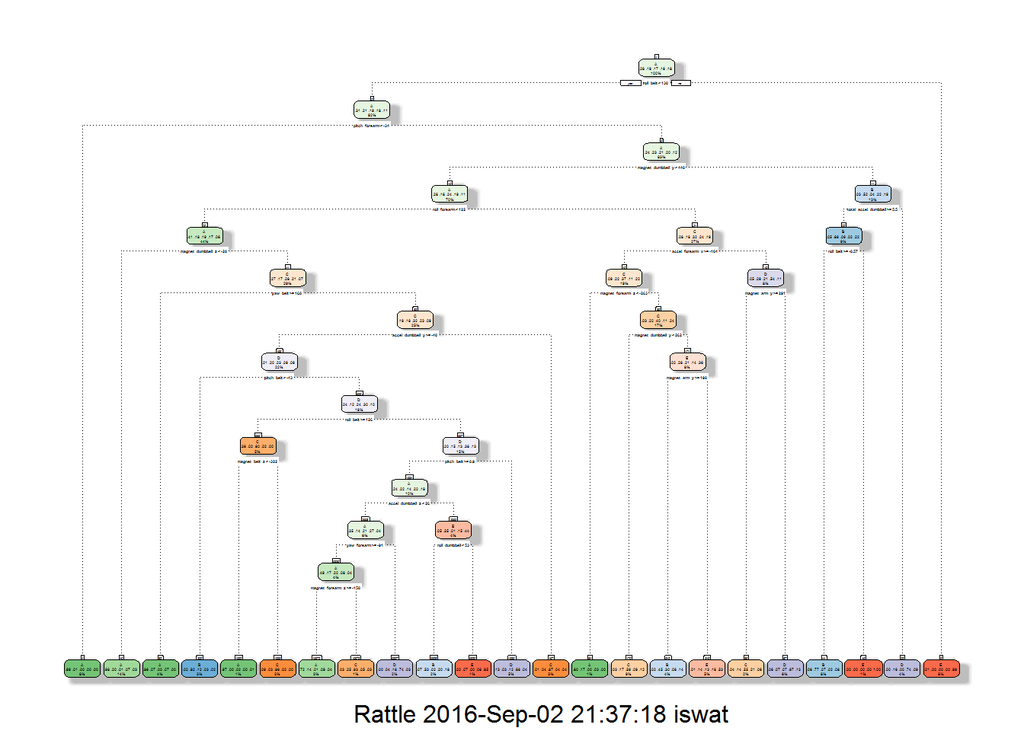

```r
modrpart <- rpart(classe ~ ., data=modTrain, method="class")
fancyRpartPlot(modrpart)
```

## Assessing Accuracy

Let’s take a look at how accurate our model is

```r
predrpart <- predict(modrpart,  modTest, type = "class")
accrpart <- confusionMatrix(predrpart, modTest$classe)$overall[1]
accrpart
```

```
##  Accuracy
## 0.7451147
```

It looks like our model has a ~75% accuracy on our testing set.